# Agilent Single-Channel Microarray Processing Pipeline RMarkdown (GLDS-156)

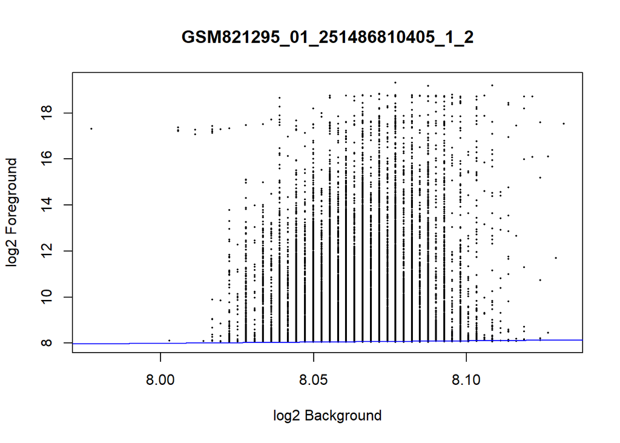

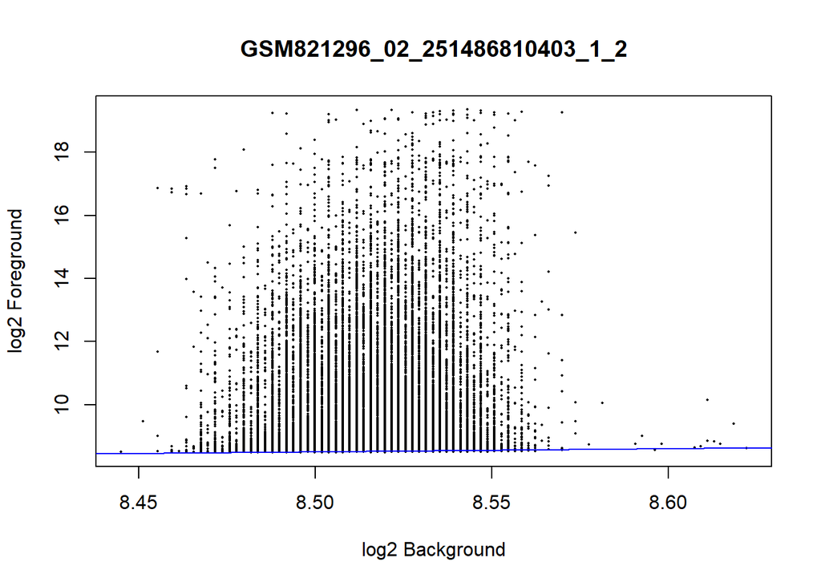

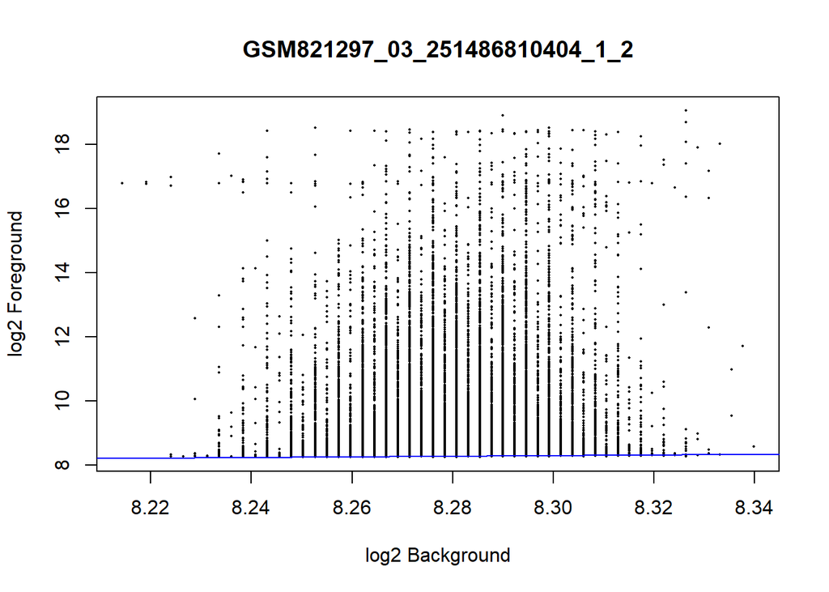

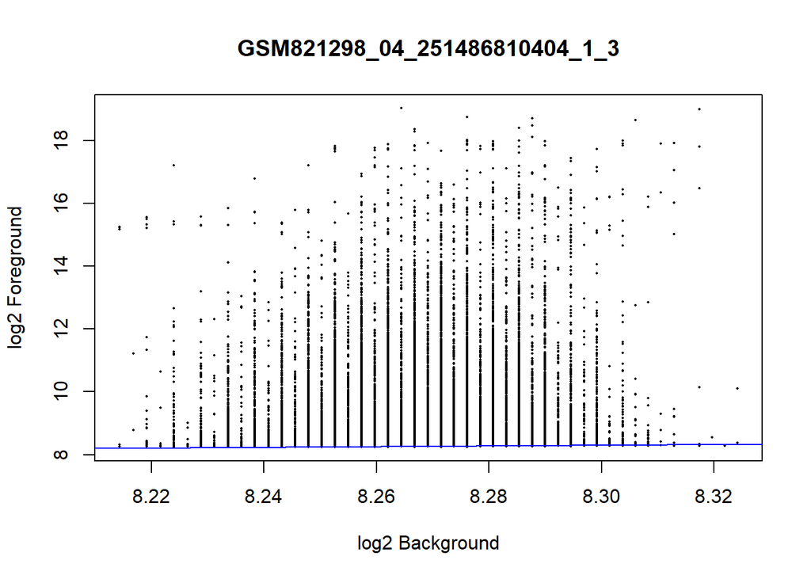

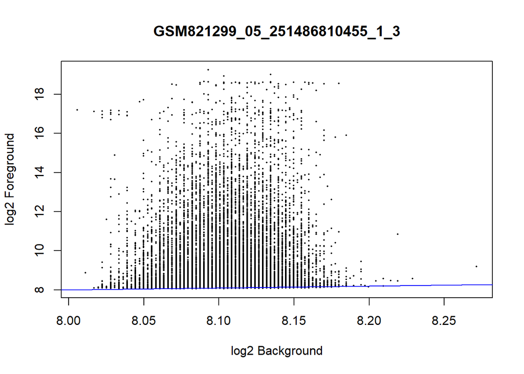

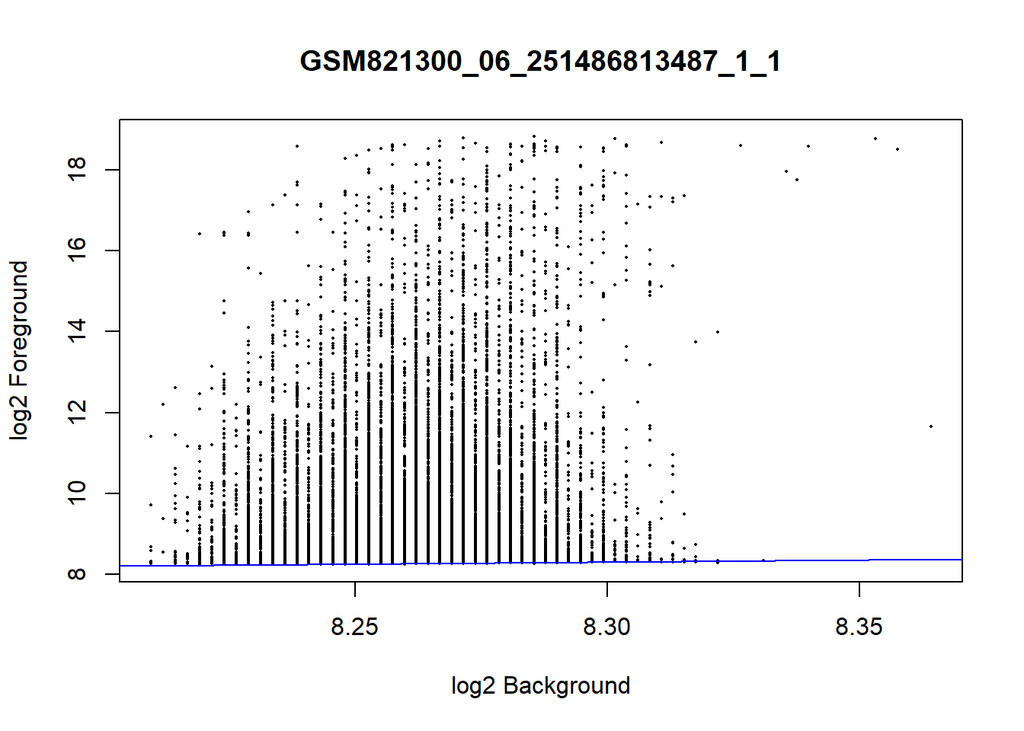

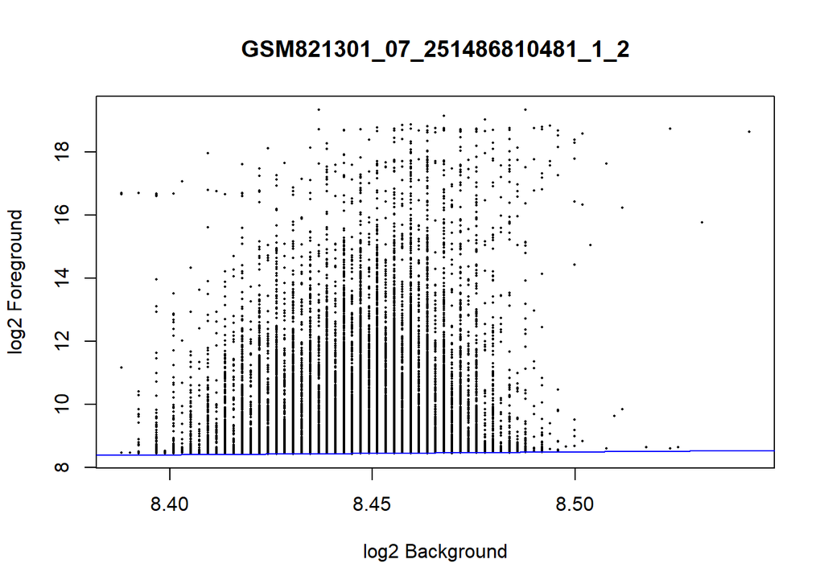

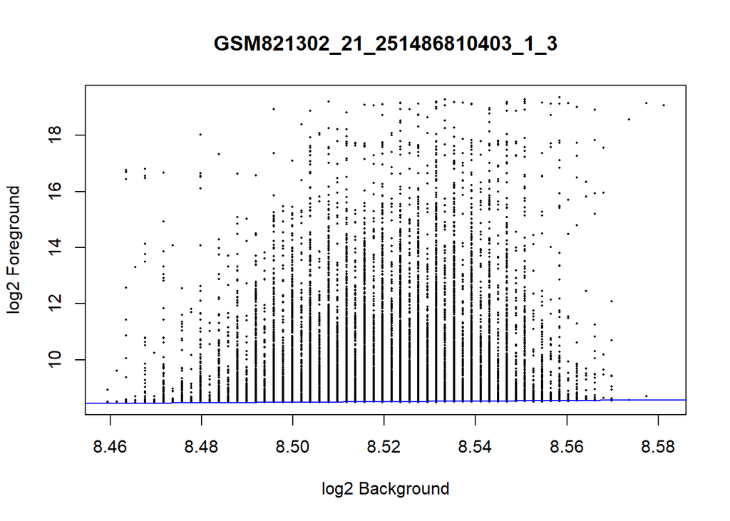

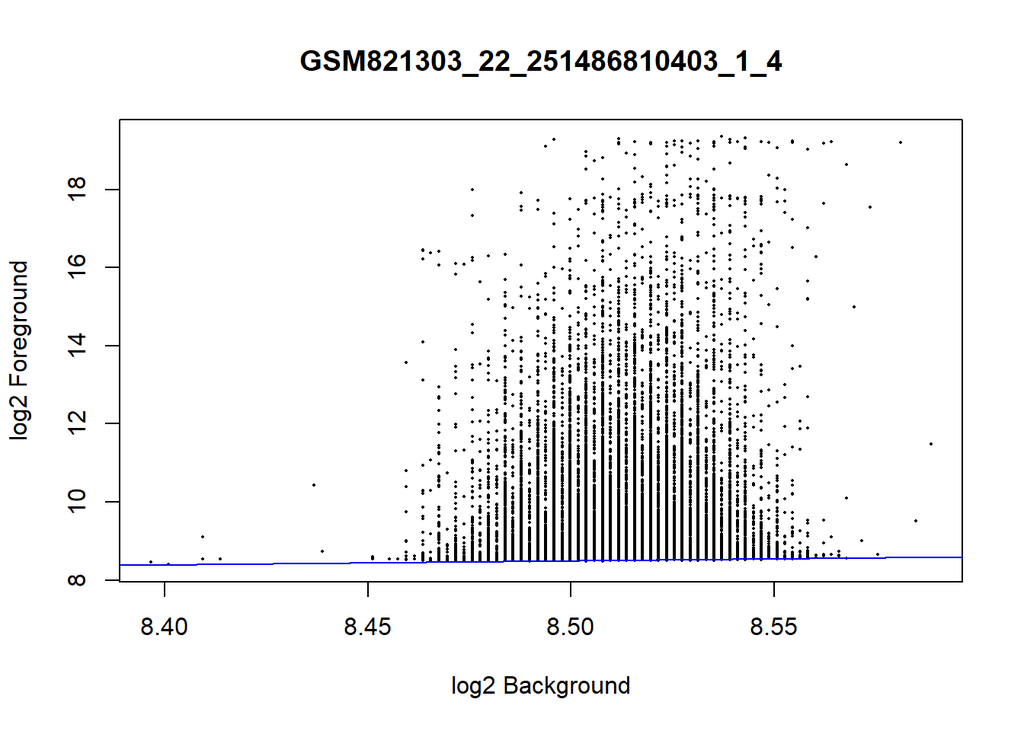

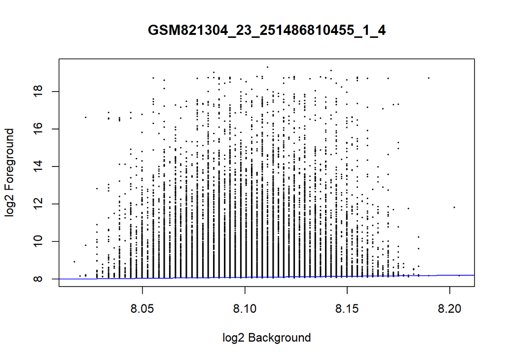

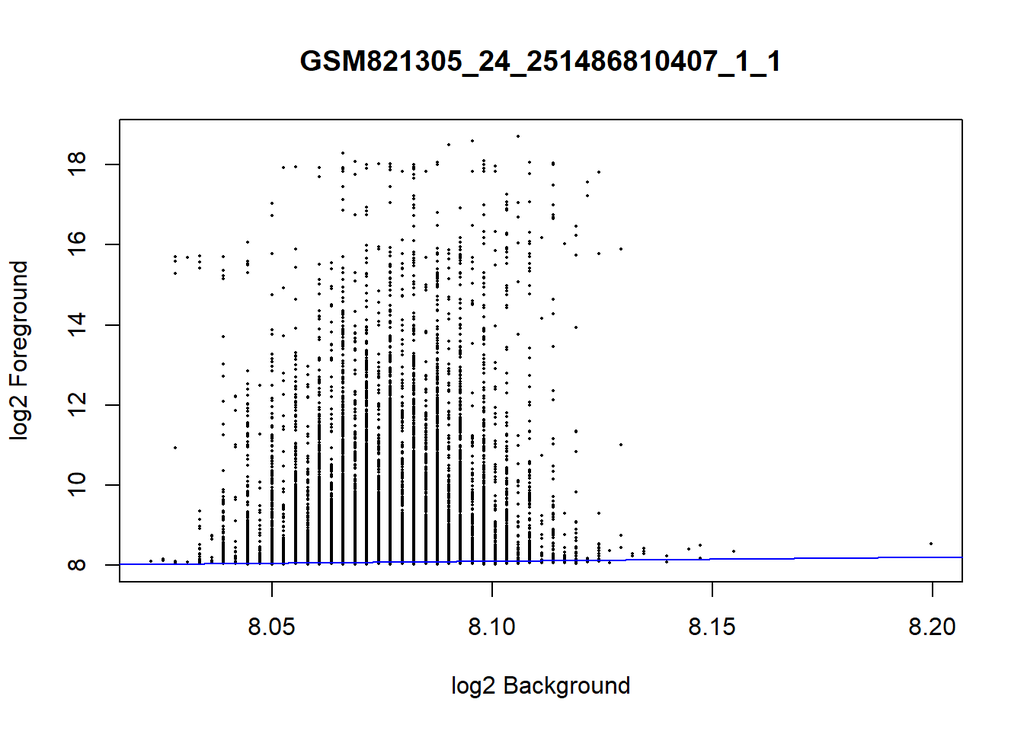

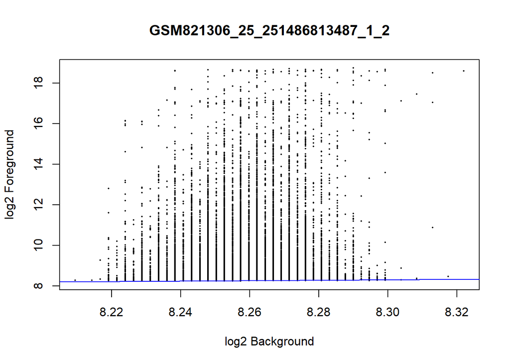

[6 more figures not shown]

```r
# This code block uses the plotFB() function from limma to generate a FB plot to compare the foreground and background intensities in each sample.
count = 0
for (sample_name in colnames(raw_data$E)) {
    count = count + 1
    plotFB(raw_data, array = count, xlab = "log2 Background", ylab = "log2 Foreground", main = sample_name)
}
```

- raw_data = EListRaw object containing the raw expression values and information about them
- array = specifying which array (sample) to use as the data
- xlab = label for the x axis
- ylab = label for the y axis
- main = title for the plot

## Normalization of the Data

After making sure that the raw data was formatted properly, I moved on to removing a lot of the variation in the gene expression data that comes from external sources (i.e. Sample preparation, labeling, hybridization) by performing normalization on the raw data. For this step, I was able to use a couple other functions from Limma called backgroundCorrect() to subtract the foreground intensities from the background intensities and normalizeBetweenArrays() to normalize the data.

```r
corrected_data <- limma::backgroundCorrect(raw_data, method = "normexp", verbose=TRUE)
```

```
## Array 1 corrected
## Array 2 corrected
## Array 3 corrected
## Array 4 corrected
## Array 5 corrected
## Array 6 corrected
## Array 7 corrected
## Array 8 corrected
## Array 9 corrected
## Array 10 corrected
## Array 11 corrected
## Array 12 corrected
## Array 13 corrected
## Array 14 corrected
## Array 15 corrected
## Array 16 corrected
## Array 17 corrected
## Array 18 corrected
```

```r
# Input: Background corrected EListRaw, Output: Elist
norm_data <- normalizeBetweenArrays(corrected_data, method = "quantile")
```

## QC of the Normalized Data

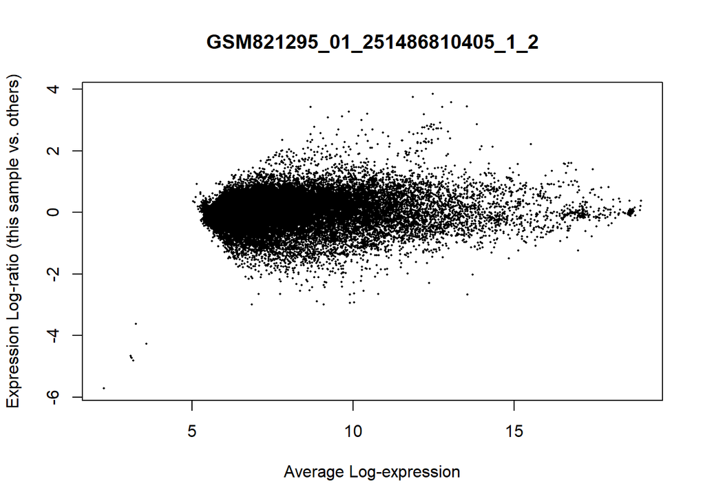

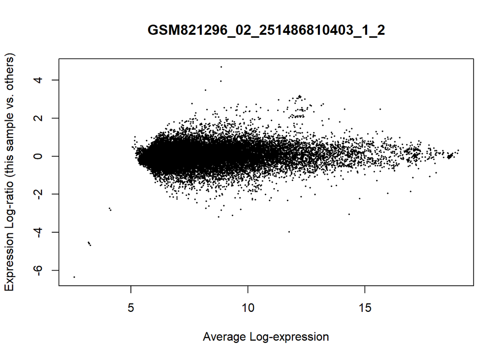

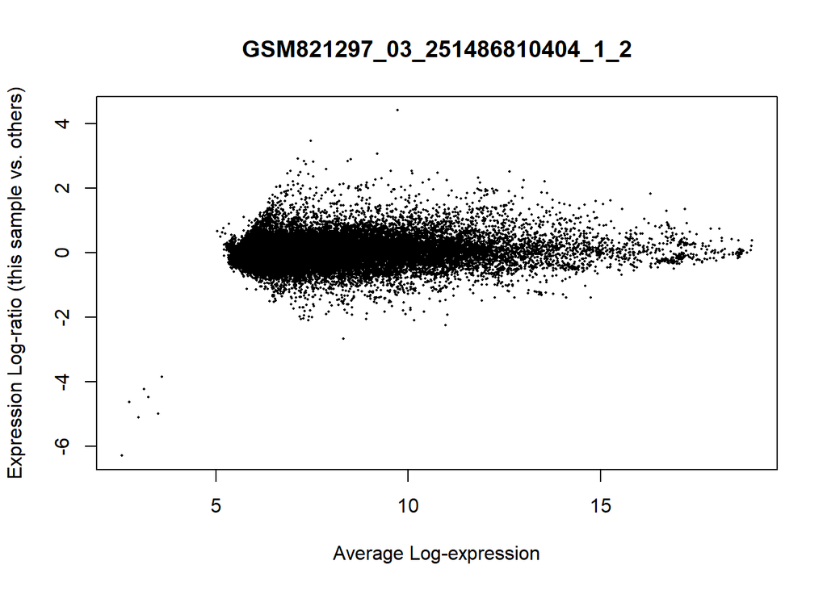

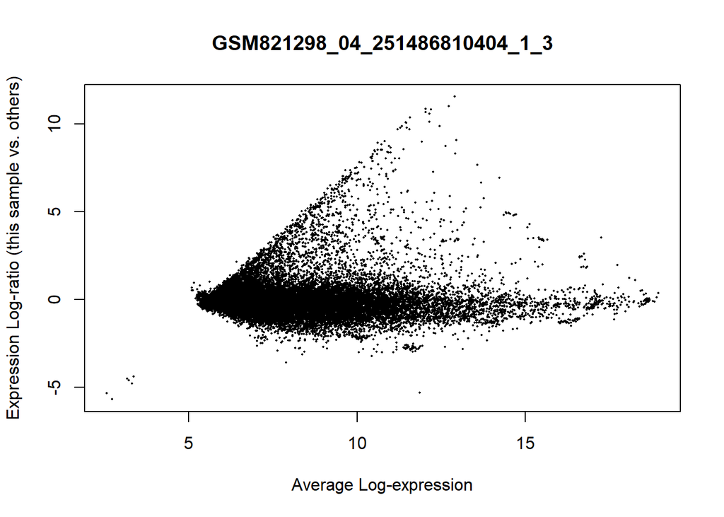

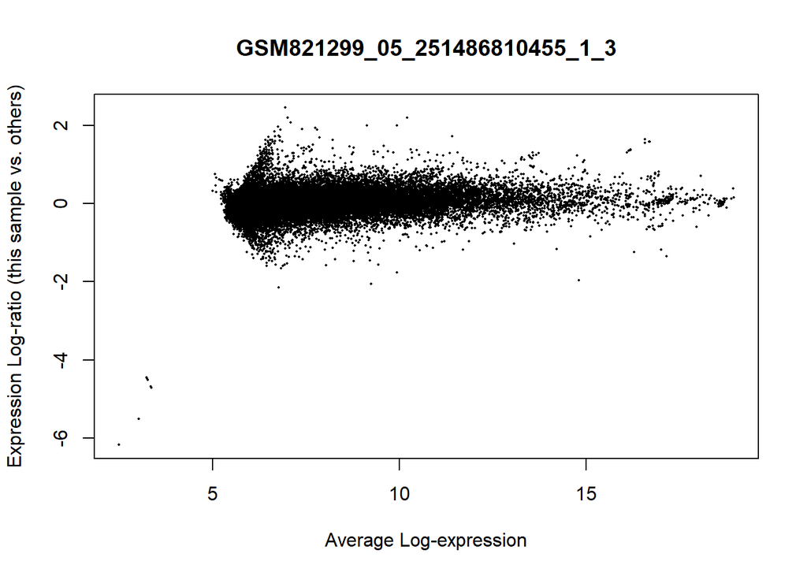

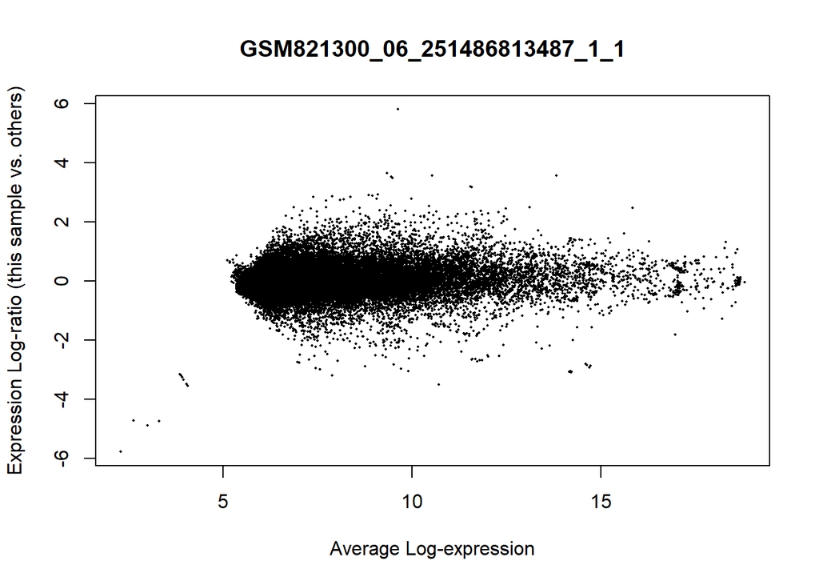

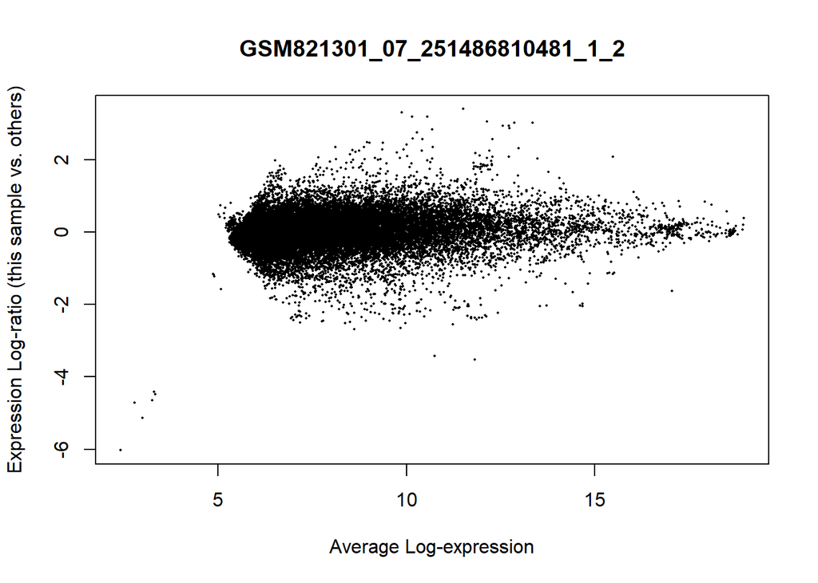

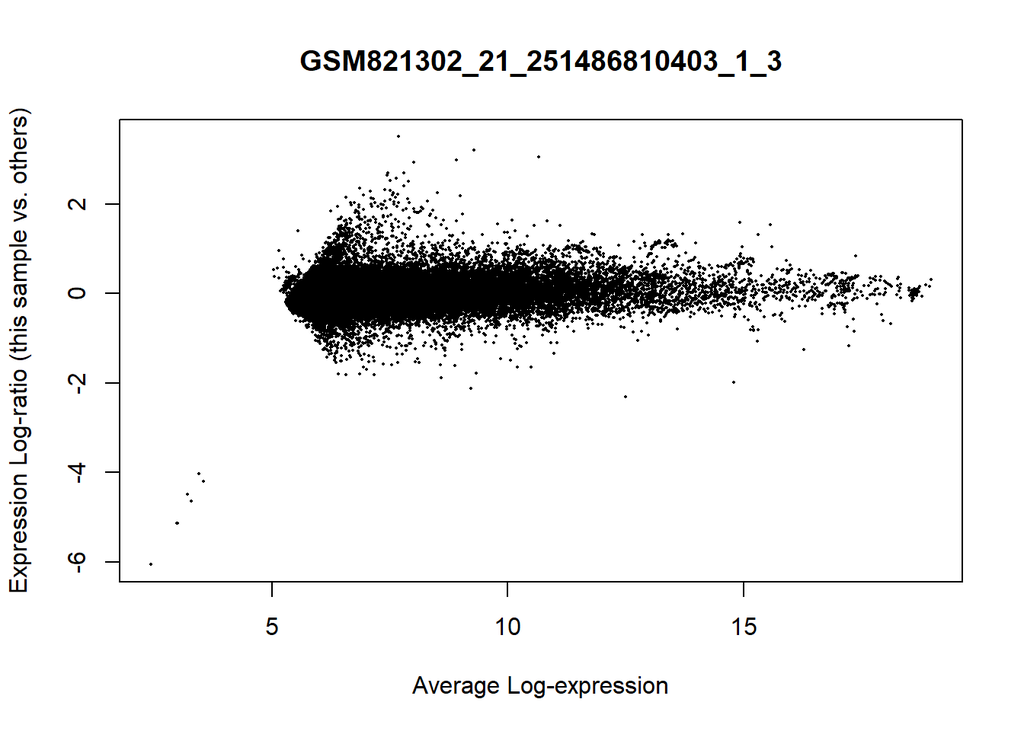

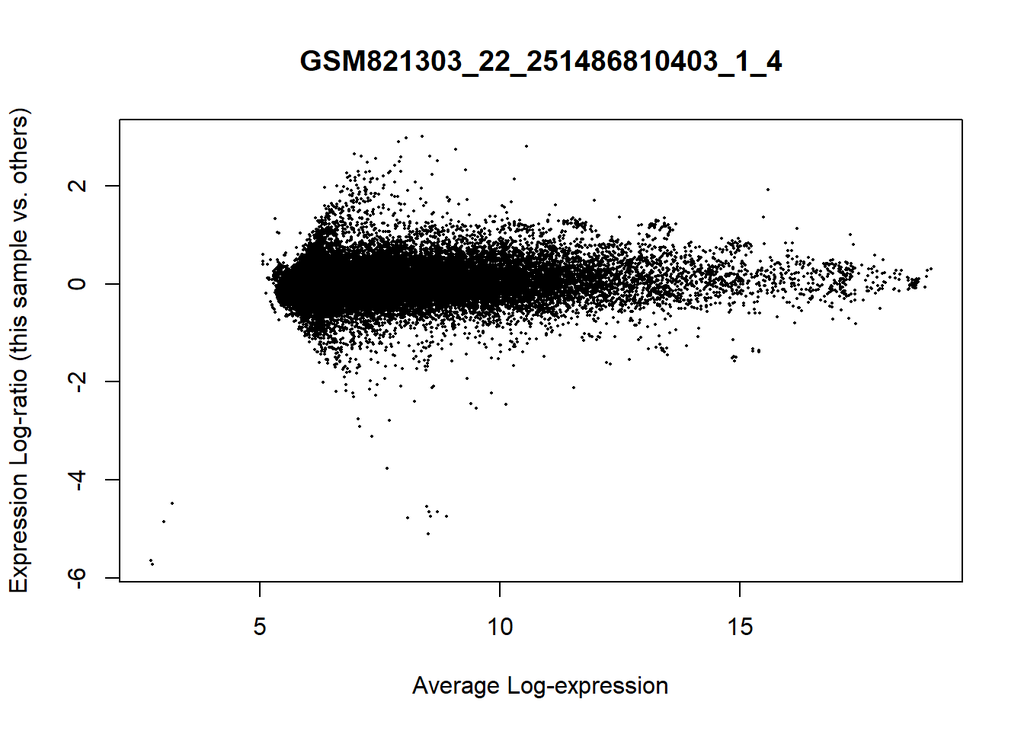

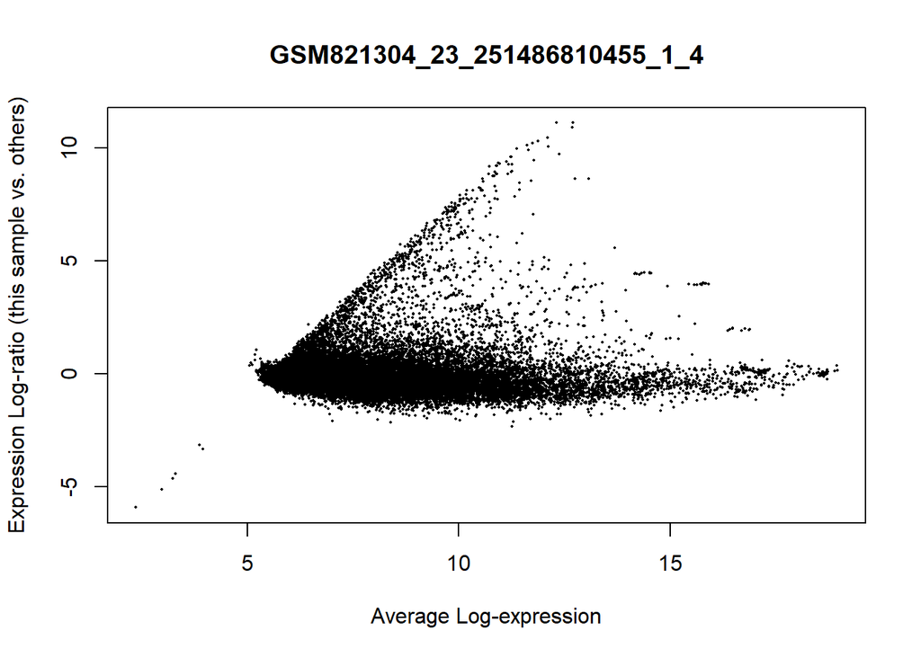

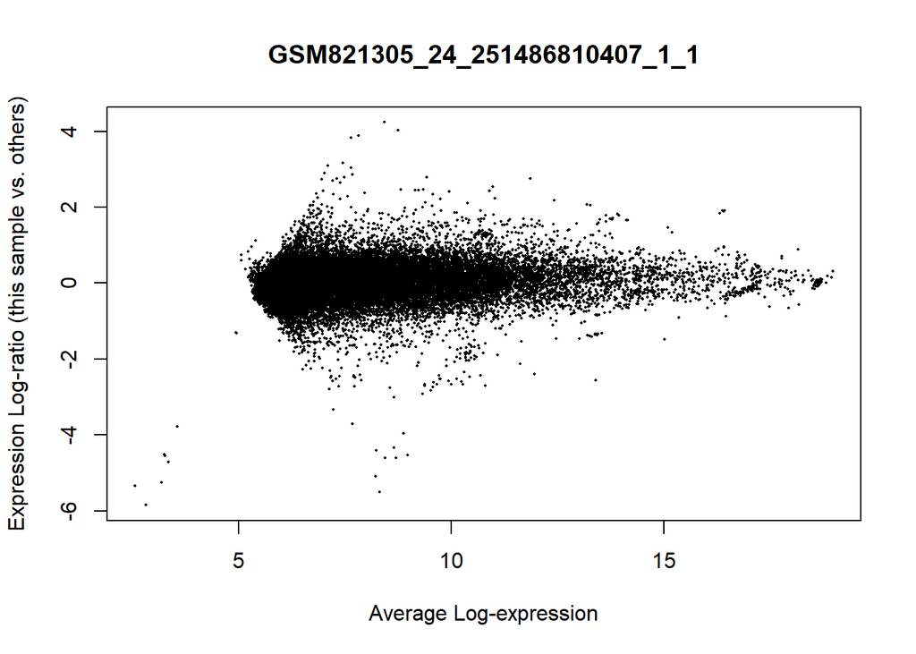

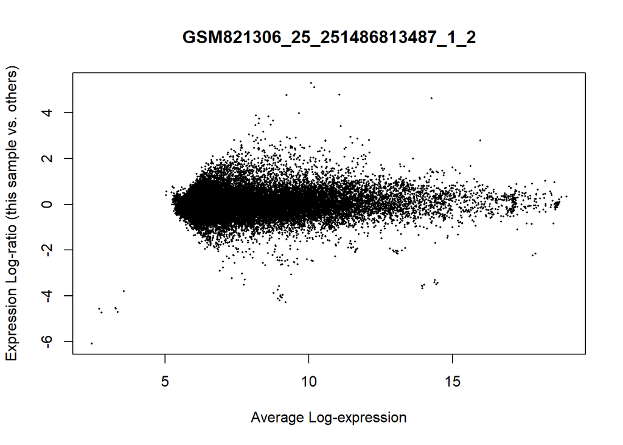

[6 more figures not shown]

```r
count = 0
for (sample_name in colnames(raw_data$E)) {
    count = count + 1
    limma::plotMA(norm_data, array = count, xlab = "Average Log-expression", ylab = "Expression Log-ratio (this sample vs. others)", main = sample_name)
}
```

## Differential Gene Analysis